# PEGA for Pine Analysis: Step 2 choose outlier groups

Katie Lotterhos

April 24, 2016

### Load data

```r
load("../data/large_files/Pine_Alpha_AveRho_WithSuperLogical.RData")
#this loads PE, results_pine3, gcontig_array, gcontig_array_names, PE_matchGWAS,PE_matchGEA


  #if(!("ash" %in% installed.packages())){install.packages("ash")}
  require(ash)
  require(fields)
```

### Plotting function plot_2D.a

plot_2D.a flips the phenotype axis

```r
plot_2D.a <- function(x,y, xlab, ylab, xlim=c(-0.3,0.3), ylim=c(-0.3,0.3), nbin, x_sub, y_sub, PE=1){
  if(PE<0){x <- -x; x_sub <- -x_sub}

  data1 <- cbind(x, y)
  data1b <- data1[complete.cases(data1),]
  if(length(xlim)==0){
    xlim_up <- max(x, na.rm=TRUE)+0.15*max(x, na.rm=TRUE)
    xlim_lower <- min(x, na.rm=TRUE)-0.15*max(x, na.rm=TRUE)
  }else{
    xlim_lower <- xlim[1]; xlim_up <- xlim[2]
  }
  if(length(ylim)==0){
    ylim_up <- max(y, na.rm=TRUE)+0.15*max(y, na.rm=TRUE)
    ylim_lower <- min(y, na.rm=TRUE)-0.15*max(y, na.rm=TRUE)
  }else{
    ylim_lower <- ylim[1]; ylim_up <- ylim[2]
  }
        binned <- bin2(data1b,
                 matrix(c(xlim_lower,xlim_up,ylim_lower,ylim_up), 2,2, byrow=TRUE),
                 nbin=c(nbin,nbin))
    binned$nc[binned$nc==0]=NA
    image(seq(xlim_lower,xlim_up,length.out = nbin),
               seq(ylim_lower,ylim_up, length.out=nbin),
               binned$nc,
             xlab=xlab, ylab=ylab, add=FALSE,
             col=grey.colors(75, 0.25,0.9),
             xaxt="n", yaxt="n", bty="n")
    points(x_sub, y_sub, pch=24, cex=1, col="magenta", bg="orange")

    lines(c(-100,100), c(0,0), col="grey") #add x axis
    lines(c(0,0), c(-100,100), col="grey") # add y axis
    if (abs(PE)>0.1){
      abline(lm(y~x), lwd=2)
      m <- lm(y_sub~x_sub)
      if(summary(m)$coef[2,4] < 1e-01){abline(m, col="orange", lwd=2)}
      }
    text(xlim_up*0.05, ylim_up*0.95, "+", cex=2, col="grey")
    text(xlim_up*0.05, ylim_lower*0.95, "-", cex=2, col="grey")
    if(PE>0){
      text(xlim_up*0.95,ylim_up*0.05,"+", cex=2, col="grey"); text(xlim_lower*0.95,ylim_up*0.05,"-", cex=2, col="grey")
    }
    if(PE<0){
       text(xlim_up*0.95,ylim_up*0.05,"-", cex=2, col="grey"); text(xlim_lower*0.95,ylim_up*0.05,"+", cex=2, col="grey")
    }
    text(xlim_up*0.75,ylim_lower*0.95, paste("PE =", PE), cex=1.2)
} # end plot_2D.a
```

### Plotting function plot_2D.b

plot_2D.b does not flip the phenotype axis. Instead it colors the quadrant for the expected direction based on the PE association

```r
plot_2D.b <- function(x,y, xlab, ylab, xlim=c(-0.3,0.3), ylim=c(-0.3,0.3), nbin, x_sub, y_sub, x_sub_green=NULL, y_sub_green=NULL, x_sub_blue=NULL, y_sub_blue=NULL,x_sub_golden=NULL,y_sub_golden=NULL, PE=1){
  #if(PE<0){x <- -x; x_sub <- -x_sub}

  data1 <- cbind(x, y)
  data1b <- data1[complete.cases(data1),]
  if(length(xlim)==0){
    xlim_up <- max(x, na.rm=TRUE)+0.15*max(x, na.rm=TRUE)
    xlim_lower <- min(x, na.rm=TRUE)-0.15*max(x, na.rm=TRUE)
  }else{
    xlim_lower <- xlim[1]; xlim_up <- xlim[2]
  }
  if(length(ylim)==0){
    ylim_up <- max(y, na.rm=TRUE)+0.15*max(y, na.rm=TRUE)
    ylim_lower <- min(y, na.rm=TRUE)-0.15*max(y, na.rm=TRUE)
  }else{
    ylim_lower <- ylim[1]; ylim_up <- ylim[2]
  }
        binned <- bin2(data1b,
                 matrix(c(xlim_lower,xlim_up,ylim_lower,ylim_up), 2,2, byrow=TRUE),
                 nbin=c(nbin,nbin))
    binned$nc[binned$nc==0]=NA
    image(seq(xlim_lower,xlim_up,length.out = nbin),
               seq(ylim_lower,ylim_up, length.out=nbin),
               binned$nc,
             xlab=xlab, ylab=ylab, add=FALSE,
             col=grey.colors(75, 0.25,0.9),
             xaxt="n", yaxt="n", bty="n")
    if(PE > 0.1){
      polygon(c(0,1,1,0,0), c(0,0,1,1,0),col=rgb(0,0,0,0.1))
      polygon(c(0,-1,-1,0,0), c(0,0,-1,-1,0), col=rgb(0,0,0,0.1))
      }
    if(PE < -0.1){
      polygon(c(0,-1,-1,0,0), c(0,0,1,1,0),col=rgb(0,0,0,0.1))
      polygon(c(0,1,1,0,0), c(0,0,-1,-1,0),col=rgb(0,0,0,0.1))
      }
    points(x_sub, y_sub, pch=24, cex=1, col="magenta", bg="orange")

    lines(c(-100,100), c(0,0), col="grey") #add x axis
    lines(c(0,0), c(-100,100), col="grey") # add y axis
    P <- 0.005 # cutoff for linear model significance
    if (abs(PE)>0.1){
      abline(lm(y~x), lwd=2)
      if(length(x_sub)>5){
        m <- lm(y_sub~x_sub)
        if(summary(m)$coef[2,4] < P){abline(m, col="orange", lwd=2)}
        }
      }

    if(length(x_sub_green)>0){
      points(x_sub_green, y_sub_green, pch=24, cex=1, col="darkgreen", bg="green")
      if (abs(PE)>0.1 & length(x_sub_green)>5){
        m <- lm(y_sub_green~x_sub_green)
        if(summary(m)$coef[2,4] < P){abline(m, col="green", lwd=2)}
      }
    }#end if x_sub_green
    if(length(x_sub_blue)>0){
      points(x_sub_blue, y_sub_blue, pch=24, cex=1, col="blue", bg="lightblue")
      if (abs(PE)>0.1 & length(x_sub_blue)>5){
        m <- lm(y_sub_blue~x_sub_blue)
        if(summary(m)$coef[2,4] < P){abline(m, col="blue", lwd=2)}
      }
    }#end if x_sub_blue
      if(length(x_sub_golden)>0){
      points(x_sub_golden, y_sub_golden, pch=24, cex=1, col="darkgoldenrod4", bg="darkgoldenrod")
      if (abs(PE)>0.1 & length(x_sub_golden)>5){
        m <- lm(y_sub_golden~x_sub_golden)
        if(summary(m)$coef[2,4] < P){abline(m, col="darkgoldenrod", lwd=2)}
      }
    }#end if x_sub_blue


    text(xlim_up*0.05, ylim_up*0.95, "+", cex=2, col="black")
    text(xlim_up*0.05, ylim_lower*0.95, "-", cex=2, col="black")

  text(xlim_up*0.95,ylim_up*0.05,"+", cex=2, col="black"); text(xlim_lower*0.95,ylim_up*0.05,"-", cex=2, col="black")

    text(xlim_up*0.75,ylim_lower*0.95, paste("PE =", PE), cex=1.2)
} # end plot_2D.b
```

### Plotting function for muliple panels, ordered by dendogram of covariances among phenotypes and environments

```r
head(PE)
```

```
##    Environment                   Phenotype pine_correlation
## 45    Latitude      ColdInjuryFallS02_Mean            -0.42
## 44         CMD                  BudSet_day             0.40
## 66        MCMT      ColdInjuryFallS02_Mean             0.38
## 67    Latitude ColdInjuryMidWinterS02_Mean            -0.37
## 46         DD0      ColdInjuryFallS02_Mean            -0.37
## 43         SHM                  BudSet_day             0.37
##    spruce_correlation PhenAbb HeatmapOrder_Phen_Pine
## 45              -0.74     FCI                     11
## 44               0.33      BS                      3
## 66               0.76     FCI                     11
## 67              -0.62     WCI                     10
## 46              -0.74     FCI                     11
## 43               0.25      BS                      3
##    HeatmapOrder_Envi_Pine
## 45                     NA
## 44                     NA
## 66                     NA
## 67                     NA
## 46                     NA
## 43                     NA
```

```r
load("../../20160125 heatmap denograms envi pheno/PineHeatmap.Rdata")
# loads env,env_clust,phen,phen_clust,EvP, EvPclust
  # env, phen, and EvP are correlation matrices based on raw data
  # env_clust and phen_clust are heatmap.2 objects showing how variables were ordered
names(env_clust)
```

```
## [1] "rowInd"        "colInd"        "call"          "carpet"
## [5] "rowDendrogram" "colDendrogram" "breaks"        "col"
## [9] "colorTable"
```

```r
(xorder <- rownames(env_clust$carpet)) # plotted in x axis in this order
```

```
##  [1] "bFFP"      "ELEVATION" "MSP"       "LONG"      "DD_0"
##  [6] "LAT"       "TD"        "PAS"       "MAP"       "MAT"
## [11] "MCMT"      "EMT"       "FFP"       "eFFP"      "NFFD"
## [16] "AHM"       "CMD"       "SHM"       "Eref"      "EXT"
## [21] "MWMT"      "DD5"
```

```r
colnames(env_clust$carpet) # plotted in y axis in this order
```

```
##  [1] "DD5: Degree-days above 5C"
##  [2] "MWMT: Mean warmest month temperature (C)"
##  [3] "EXT: Extreme maximum temperature over 30 years"
##  [4] "Eref: Hargreaves reference evaporation (mm)"
##  [5] "SHM: Summer heat-moisture index ((MWMT)/(MSP/1000))"
##  [6] "CMD: Hargreaves climatic moisture deficit (mm)"
##  [7] "AHM: Annual heat-moisture index (MAT+10)/(MAP/1000))"
##  [8] "NFFD: Number of frost-free days"
##  [9] "eFFP: Day of the year frost-free period ends"
## [10] "FFP: Frost-free period (days)"
## [11] "EMT: Extreme minimum temperature over 30 years"
## [12] "MCMT: Mean coldest month temperature (C)"
## [13] "MAT: Mean annual temperature (C)"
## [14] "MAP: Mean annual precipitation (mm)"
## [15] "PAS: Precipitation as snow (mm)"
## [16] "TD: Temperature difference (MWMT - MCMT)"
## [17] "LAT: Latitude"
## [18] "DD_0: Degree-days below 0C"
## [19] "LONG: Longitude"
## [20] "MSP: May to September precipitation (mm)"
## [21] "ELEVATION: Elevation"
## [22] "bFFP: Day of the year frost-free period begins"
```

```r
(yorder <- rev(rownames(phen_clust$carpet))) # plotted phenotypes in this order
```

```
##  [1] "RWSW" "SHWT" "DIAM" "RTWT" "HS2"  "HS1"  "BS"   "RSW"  "BB"   "MGR"
## [11] "D05G" "D95G" "5D95" "LGD"  "WCI"  "FCI"  "SCI"
```

```r
#yorder <- yorder[-4] # remove root weight
pheno_ind <- c(1:3,5:17)
colnames(phen_clust$carpet) # plotted in y axis in this order
```

```
##  [1] "RWSW: Root weight + shoot weight" "SHWT: Shoot weight"
##  [3] "DIAM: Diameter"                   "RTWT: Root weight"
##  [5] "HS2: Height (season 2)"           "HS1: Height (season 1)"
##  [7] "BS: Budset"                       "RSW: Root:shoot weight"
##  [9] "BB: Budbreak"                     "MGR: Maximum growth rate"
## [11] "D05G: days to 5% growth"          "D95G: days to 95% growth"
## [13] "5D95: Days from 5% to 95% growth" "LGD: Linear growth (days)"
## [15] "WCI: Winter cold injury"          "FCI: Fall cold injury"
## [17] "SCI: Spring cold injury"
```

```r
#### Function for plotting according to dendogram order
MakeOutlierPlot <- function(filename, Group_logical, envi_ind=1:22, pheno_ind=c(1:3,5:17), xlim=c(-0.3,0.3), ylim=c(-0.3,0.3),  width=50, height=66, type="Bayenv", Green_logical=NULL, Blue_logical=NULL, Golden_logical=NULL){
    #type = "Bayenv" or "Raw"

  pdf(file = filename,width=width,height=height)
  par(mfrow=c(length(envi_ind),length(pheno_ind)), mar=c(2,2,0,0), oma=c(6,6,6,0))
  for (i in envi_ind){ ## loop through environments
    for (j in pheno_ind){ ## loop through phenotypes

      ### y = get GEA column
      if(type=="Bayenv"){gea_col <- grep(paste("^",xorder[i],"_rhoave", sep=""),names(results_pine3))}
      if(type=="Raw"){gea_col <- grep(paste("^",xorder[i],"_raw_rho", sep=""),names(results_pine3))}

      y <- results_pine3[,gea_col] #carrot is needed for FFP

      ### x = get GPA column
        gpa1 <- PE_matchGWAS$Phenotype_GWAS[which(PE_matchGWAS$Abb == yorder[j])]
        if(gpa1=="root_wt__shoot_wt_p"){
          gpa1 <- "root_wt_shoot_wt_p"}
        if(gpa1=="root_wt__shoot_wt_p_1"){
          gpa1 <- "root_wt_shoot_wt_p_1"}

        if(type=="Bayenv"){
          gpa2<- gsub("_p","",gpa1)
          gpa_col <- grep(paste("^",gpa2, "_rhoave_BAYENV", sep=""), names(results_pine3))
        }
        if(type=="Raw"){gpa_col <- grep(paste("^",gpa1,"_raw_rho", sep=""), names(results_pine3))}

      x <- results_pine3[,gpa_col]
    # pecorr = get PE
      pecorr <- PE$pine_correlation[(PE$Environment==PE_matchGEA$Environment_PE[PE_matchGEA$Environment_GEA == xorder[i]]) & PE$PhenAbb==yorder[j]]

      # make plot2D.a
      plot_2D.b(x,y,
         xlab= "", xlim=xlim,
         ylab= "" , ylim=ylim,
         nbin=100,
         x_sub=x[Group_logical],
         y_sub=y[Group_logical],
         PE=pecorr,
         x_sub_green=x[Green_logical],
         y_sub_green=y[Green_logical],
         x_sub_blue=x[Blue_logical],
         y_sub_blue=y[Blue_logical],
         x_sub_golden=x[Golden_logical],
         y_sub_golden=y[Golden_logical]
         )
      mtext(xorder[i], side=2)
      mtext(yorder[j], side=1)
    } #end j loop
    print(i)
    } #end i loop
  dev.off()

}# end function
```

### Covariance based on random sample of 1 SNP from each gcontig

I realized that I need a second function to calculate covariance based on SNP sampled from independent gtcontigs that match MAF to an observed sample.

```r
  getInd2 <- function(gtcontig, dataframe){
    return(which(dataframe$gtcontig %in% gtcontig))
  }

length(gtcontig_array_names)
```

```
## [1] 86566
```

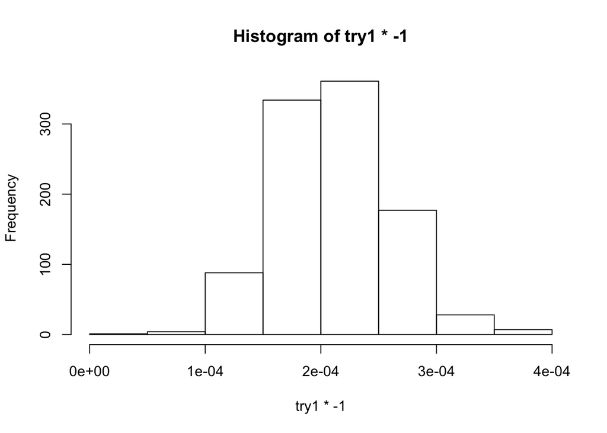

```r
getOneIndexEach_gtcontig_Cov <- function(array, array_names, value1, value2,  num, logicvect=NULL){
  ## each index in array is a gtcontig and holds the indexes of SNPs
    ## that can be sampled, array_names is the gtcontig name
  ## value1 and value2 are vectors of values with length (nrow(unlist(array))) to calculate the covariance between
  ## num is the number of gtcontigs to draw from the data
  ## logicvect is a vector of T/F with length(array_names)
  ## indicating whether or not to sample that gtcontig
  ind <- 1:length(array_names)
  ## the following code returns the gtcontigs to sample from gtcontig_array
  if(length(logicvect)==0){
      array_ind <- sample(ind, num, replace=FALSE)
    }else{
      array_ind <- sample(ind, num, replace=FALSE, prob=logicvect)
    }
  ## the following code returns the row indices in results_pine3 to sample values from
  SNProws <- sapply(array_ind, function(i){sample(array[[i]], 1)})
  return(cov(value1[SNProws], value2[SNProws]))
}


try1 <- replicate(1000, getOneIndexEach_gtcontig_Cov(gtcontig_array, gtcontig_array_names, results_pine3$LAT_rhoave, results_pine3$Fall_cold_injury_rhoave_BAYENV,  219, logicvect=NULL))
hist(try1*-1)  # negative PE association
```